# Unit 9 HW

Ben Goodwin

3/14/2021

## PCA Conceptual questions

1. TRUE/FALSE Principle component analysis is a predictive modeling technique such as linear regression and lda.

   False-PCA is more of an EDA tool
2. TRUE or FALSE? Technically speaking, PCA should not be applied to categorical variables.

   True- It is challenging to find a suitable way to represent distances between variable categories
3. An analyst conducts a pca on continuous variables 1 through 20 and settled on reducing the variable down to 4. The analyst then proceeds to conduct a linear regression using the 4 pcs components as predictors and the response is variable 1. Why is this a horrible idea?

   This is a terrible idea because PCA is meant to be used on predictor variables, not outcome ones.
4. Why is it important to conduct PCA on standardized variables (aka using the correlation matrix)?

   Variable scale is hugely important when it comes to PCA, they must be standardized otherwise, the loadings will not serve any purpose.

## Exercise #1 PCA Basics

```r
library(Lahman)
data(Batting)
index<-which(Batting$yearID==2016)
Bat16<-Batting[index,]
summary(Bat16)
```

```
##    playerID             yearID         stint           teamID     lgID
##  Length:1483        Min.   :2016   Min.   :1.000   ATL    :  60   AA:  0
##  Class :character   1st Qu.:2016   1st Qu.:1.000   SDN    :  58   AL:734
##  Mode  :character   Median :2016   Median :1.000   LAN    :  55   FL:  0
##                     Mean   :2016   Mean   :1.092   PIT    :  55   NA:  0
##                     3rd Qu.:2016   3rd Qu.:1.000   SEA    :  54   NL:749
##                     Max.   :2016   Max.   :4.000   LAA    :  53   PL:  0
##                                                    (Other):1148   UA:  0
##        G                AB              R                H
##  Min.   :  1.00   Min.   :  0.0   Min.   :  0.00   Min.   :  0.00
##  1st Qu.: 13.00   1st Qu.:  0.0   1st Qu.:  0.00   1st Qu.:  0.00
##  Median : 31.00   Median : 11.0   Median :  1.00   Median :  1.00
##  Mean   : 47.51   Mean   :111.6   Mean   : 14.66   Mean   : 28.51
##  3rd Qu.: 69.00   3rd Qu.:155.0   3rd Qu.: 18.00   3rd Qu.: 36.00
##  Max.   :162.00   Max.   :672.0   Max.   :123.00   Max.   :216.00
##
##       X2B              X3B                HR              RBI
##  Min.   : 0.000   Min.   : 0.0000   Min.   : 0.000   Min.   :  0.00
##  1st Qu.: 0.000   1st Qu.: 0.0000   1st Qu.: 0.000   1st Qu.:  0.00
##  Median : 0.000   Median : 0.0000   Median : 0.000   Median :  0.00
##  Mean   : 5.566   Mean   : 0.5887   Mean   : 3.783   Mean   : 13.99
##  3rd Qu.: 7.000   3rd Qu.: 0.0000   3rd Qu.: 3.000   3rd Qu.: 15.50
##  Max.   :48.000   Max.   :11.0000   Max.   :47.000   Max.   :133.00
##
##        SB               CS               BB               SO
##  Min.   : 0.000   Min.   : 0.000   Min.   :  0.00   Min.   :  0.00
##  1st Qu.: 0.000   1st Qu.: 0.000   1st Qu.:  0.00   1st Qu.:  0.00
##  Median : 0.000   Median : 0.000   Median :  0.00   Median :  4.00
##  Mean   : 1.711   Mean   : 0.675   Mean   : 10.17   Mean   : 26.29
##  3rd Qu.: 1.000   3rd Qu.: 0.000   3rd Qu.: 13.00   3rd Qu.: 38.00
##  Max.   :62.000   Max.   :18.000   Max.   :116.00   Max.   :219.00
##
##       IBB               HBP               SH                SF
##  Min.   : 0.0000   Min.   : 0.000   Min.   : 0.0000   Min.   : 0.0000
##  1st Qu.: 0.0000   1st Qu.: 0.000   1st Qu.: 0.0000   1st Qu.: 0.0000
##  Median : 0.0000   Median : 0.000   Median : 0.0000   Median : 0.0000
##  Mean   : 0.6285   Mean   : 1.113   Mean   : 0.6912   Mean   : 0.8186
##  3rd Qu.: 0.0000   3rd Qu.: 1.000   3rd Qu.: 1.0000   3rd Qu.: 1.0000
##  Max.   :20.0000   Max.   :24.000   Max.   :13.0000   Max.   :15.0000
##
##       GIDP
##  Min.   : 0.000
##  1st Qu.: 0.000
##  Median : 0.000
##  Mean   : 2.508
##  3rd Qu.: 3.000
##  Max.   :26.000
##
```

For those of you who do not know too much about baseball, the first 5 variables are just general information, G is the number of games played while the rest are information for players batting ability. G is games, AB is number of batting attempts, R-Runs, H-hits, X2B and X3B are doubles and triples, HR-homeruns, RBI-Runs Batted In. These are all general information on how well the batters can hit the ball. SB-stolen bases and CS- caught stealing are statistics about a players ability to run the bases, BB and IBB are when the batter gets a walk, HBP is hit by a pitch, SH and SF are sacrifice hit and fly’s where the player doesn’t get a hit but their hit is still productive, and lastley GIDP is grounded into double plays.

Sports data sets lend themselves well to PCA. We will use this example to go through similar concepts discussed in class. For starters lets just start off with just a few variables in the set to verify PCA is doing what we expect it to. Here is a quick scatterplot matrix. The variables here are highly correlated with each other.

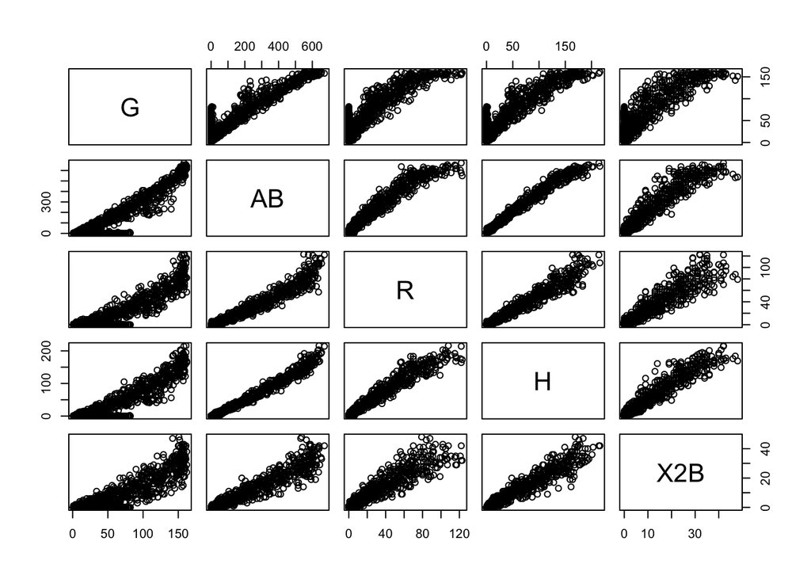

```r
reduced<-Bat16[,6:10]
pairs(reduced)
```

Let’s take a quick look at the summary statistics and in particular lets calculate the variance of each variable and add them up to obtain the total variance.

```r
apply(reduced,2,summary)
```

```
##                 G       AB         R         H       X2B
## Min.      1.00000   0.0000   0.00000   0.00000  0.000000
## 1st Qu.  13.00000   0.0000   0.00000   0.00000  0.000000
## Median   31.00000  11.0000   1.00000   1.00000  0.000000
## Mean     47.50573 111.6392  14.66217  28.50708  5.565745
## 3rd Qu.  69.00000 155.0000  18.00000  36.00000  7.000000
## Max.    162.00000 672.0000 123.00000 216.00000 48.000000
```

```r
var.raw<-apply(reduced,2,var)
var.raw
```

```
##           G          AB           R           H         X2B
##  2054.72517 31658.76653   665.77851  2363.88035    96.32951
```

```r
#Total variance
sum(var.raw)
```

```
## [1] 36839.48
```

We have been talking about the covariance matrix a lot lately. An estiamte for any given set of continouos variables can be obtained using the cov function. You can see that the diagonals of this matrix are the same as the variances calculated one at a time from before.

```r
cov(reduced)
```

```
##             G        AB         R         H        X2B
## G   2054.7252  7423.272 1048.0832 1999.3891  391.50924
## AB  7423.2723 31658.767 4479.3423 8574.1257 1678.82164
## R   1048.0832  4479.342  665.7785 1229.5547  240.89233
## H   1999.3891  8574.126 1229.5547 2363.8803  462.93830
## X2B  391.5092  1678.822  240.8923  462.9383   96.32951
```

```r
#Another way to get total variance
sum(diag(cov(reduced)))
```

```
## [1] 36839.48
```

Running PCA is relatively straight forward. The following script conducts a PCA using the covariance matrix (nonstandardarized variables) and stores the results in an object. This object contains the eigenvectors, eigenvalue, and the new principle component vectors. Lets start by producing a correlation matrix to verify that new principle component variables are uncorrelated.

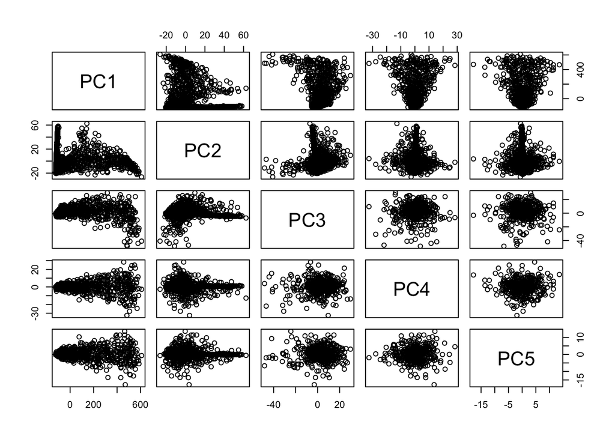

```r
pc.result<-prcomp(reduced,scale.=FALSE)
pc.scores<-pc.result$x
pairs(pc.scores)
```

```r
cor(pc.scores)
```

```
##               PC1           PC2           PC3           PC4           PC5
## PC1  1.000000e+00  3.883426e-15 -9.277437e-15  1.552181e-14 -1.433233e-14
## PC2  3.883426e-15  1.000000e+00 -7.001366e-17  5.291058e-15 -5.983462e-15
## PC3 -9.277437e-15 -7.001366e-17  1.000000e+00 -1.141962e-15 -6.650849e-16
## PC4  1.552181e-14  5.291058e-15 -1.141962e-15  1.000000e+00  3.636272e-16
## PC5 -1.433233e-14 -5.983462e-15 -6.650849e-16  3.636272e-16  1.000000e+00
```

We can again verify that the total variance in the new PC variables is exactly the same as the original data. The eigenvectors are stored inside of “pc.result” as well in the “rotation” object.

```r
var.pca<-apply(pc.scores,2,var)
var.pca
```

```
##          PC1          PC2          PC3          PC4          PC5
## 36462.584984   301.411677    50.103822    19.963419     5.416166
```

```r
#Total Variance of PC's
sum(var.pca)
```

```
## [1] 36839.48
```

```r
#Total Variance of Original Variables.
sum(var.raw)
```

```
## [1] 36839.48
```

```r
#List of eigenvectors
pc.result$rotation
```

```
##            PC1         PC2         PC3         PC4          PC5
## G   0.22024127  0.97397742 -0.05059877  0.01730636 -0.001420923
## AB  0.93156585 -0.19396824  0.30281622 -0.05283321  0.008507431
## R   0.13202633 -0.04546002 -0.57626905 -0.80501489  0.019168837
## H   0.25258860 -0.10598044 -0.73885937  0.57082967 -0.230667442
## X2B 0.04946609 -0.02111491 -0.16656204  0.15170255  0.972805577
```

A scree plot of the eigenvalues used to determine how many pc’s to keep can be plotted in the following way:

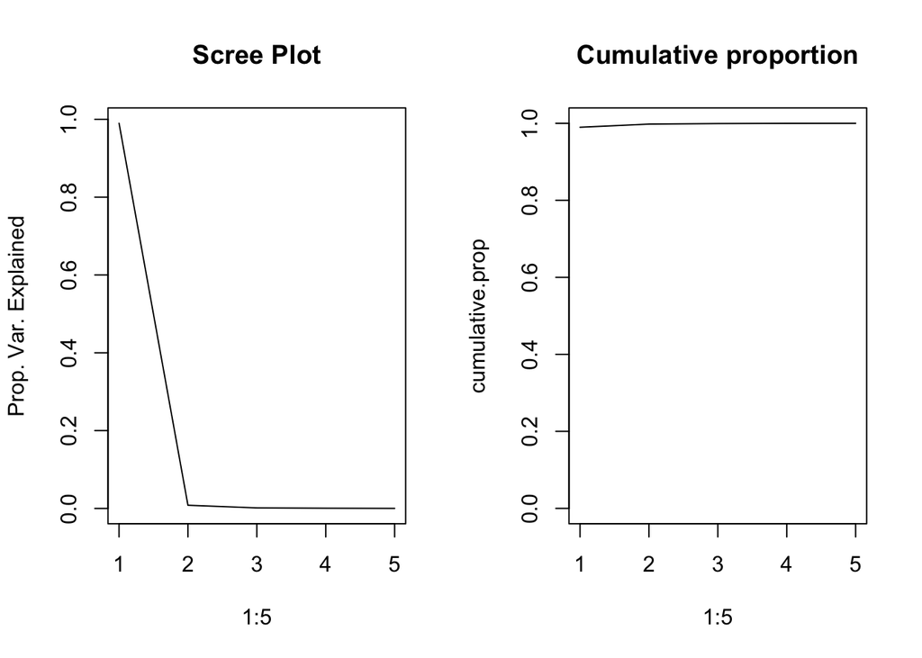

```r
par(mfrow=c(1,2))
eigenvals<-(pc.result$sdev)^2
plot(1:5,eigenvals/sum(eigenvals),type="l",main="Scree Plot",ylab="Prop. Var. Explained")
cumulative.prop<-cumsum(eigenvals/sum(eigenvals))
plot(1:5,cumulative.prop,type="l",main="Cumulative proportion",ylim=c(0,1))
```

```r
par(mfrow=c(1,1))
```

Since all of the variables are not on the same scale, we see a very similar phenomenon that we discussed in the pre live session. To conduct the pca on the correlation matrix, just set scale.=TRUE inside of the prcomp function.

## HW Assignment #1

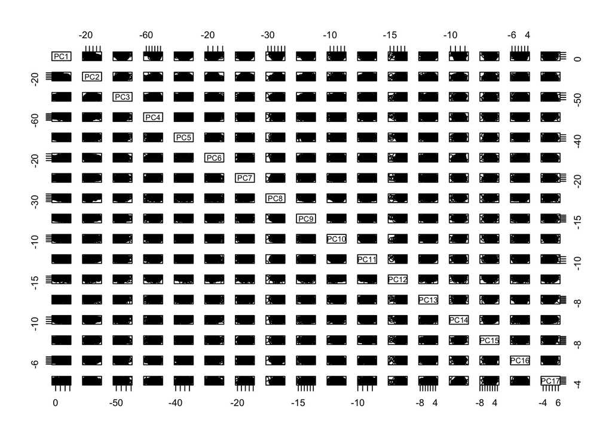

```r
batfull <- Bat16[,6:22]
pc.result2<-prcomp(batfull,scale.=FALSE)
pc.scores2<-pc.result2$x
pairs(pc.scores2)
```

```r
cor(pc.scores2)
```

```
##                PC1           PC2           PC3           PC4           PC5
## PC1   1.000000e+00 -8.225935e-14 -6.513115e-17 -7.125810e-15  1.831074e-15
## PC2  -8.225935e-14  1.000000e+00 -2.476390e-15  2.348867e-16  9.142583e-16
## PC3  -6.513115e-17 -2.476390e-15  1.000000e+00 -4.164557e-16 -1.986087e-16
## PC4  -7.125810e-15  2.348867e-16 -4.164557e-16  1.000000e+00  2.117756e-15
## PC5   1.831074e-15  9.142583e-16 -1.986087e-16  2.117756e-15  1.000000e+00
## PC6   9.627222e-15  2.196905e-16  3.057819e-16  1.598283e-15  2.041250e-15
## PC7   1.847453e-14  3.063298e-15 -6.125906e-16  1.582150e-15  1.703187e-15
## PC8  -1.025982e-14 -3.476807e-15  3.831626e-16  1.021772e-15  1.240179e-15
## PC9  -1.847341e-14 -6.842301e-15  8.306578e-17 -2.183744e-16 -1.877649e-16
## PC10 -4.849812e-15 -5.323694e-15  1.273454e-15  1.332100e-16  8.119559e-16
## PC11 -1.598617e-15 -1.988538e-15 -8.806498e-16  3.182558e-15 -9.421444e-16
## PC12  3.924110e-15  1.243093e-15 -9.061726e-17  1.010226e-15  2.342181e-16
## PC13  8.119414e-16 -3.995649e-18 -3.374084e-16  2.099940e-15 -4.127787e-16
## PC14  1.046033e-14  3.270567e-15 -2.345644e-16 -1.097005e-15 -1.224782e-15
## PC15 -1.639031e-15 -1.030404e-15 -3.354842e-16  5.042718e-16 -1.163909e-15
## PC16 -1.752310e-15 -6.786044e-16 -2.618838e-16  1.665822e-15 -2.177907e-16
## PC17 -1.313515e-15 -1.086132e-15  3.465742e-16 -3.547729e-16  4.288925e-16
##                PC6           PC7           PC8           PC9          PC10
## PC1   9.627222e-15  1.847453e-14 -1.025982e-14 -1.847341e-14 -4.849812e-15
## PC2   2.196905e-16  3.063298e-15 -3.476807e-15 -6.842301e-15 -5.323694e-15
## PC3   3.057819e-16 -6.125906e-16  3.831626e-16  8.306578e-17  1.273454e-15
## PC4   1.598283e-15  1.582150e-15  1.021772e-15 -2.183744e-16  1.332100e-16
## PC5   2.041250e-15  1.703187e-15  1.240179e-15 -1.877649e-16  8.119559e-16
## PC6   1.000000e+00  7.321460e-16 -1.597795e-15 -5.631656e-16 -1.489276e-16
## PC7   7.321460e-16  1.000000e+00 -3.287246e-16  1.036264e-15  6.546113e-16
## PC8  -1.597795e-15 -3.287246e-16  1.000000e+00 -5.472353e-16 -2.884891e-16
## PC9  -5.631656e-16  1.036264e-15 -5.472353e-16  1.000000e+00 -3.881256e-16
## PC10 -1.489276e-16  6.546113e-16 -2.884891e-16 -3.881256e-16  1.000000e+00
## PC11 -1.120155e-15  1.860638e-15 -1.517743e-15 -7.317286e-16  2.556724e-17
## PC12 -6.205188e-16 -1.638723e-16 -9.839125e-16  2.008311e-16 -4.618522e-16
## PC13 -5.248746e-17  2.811449e-16 -5.121637e-16  3.690748e-17 -5.924287e-16
## PC14  1.011205e-15 -3.391002e-16  6.571569e-16  2.024569e-16 -5.041759e-17
## PC15  4.699885e-16 -9.553449e-16  9.770837e-16 -9.114251e-17  6.923744e-16
## PC16 -1.003562e-15  8.938691e-16 -5.947671e-16  4.925667e-16 -6.363497e-16
## PC17  4.620240e-17  3.506311e-16 -2.366228e-17  5.573763e-16  1.101398e-16
##               PC11          PC12          PC13          PC14          PC15
## PC1  -1.598617e-15  3.924110e-15  8.119414e-16  1.046033e-14 -1.639031e-15
## PC2  -1.988538e-15  1.243093e-15 -3.995649e-18  3.270567e-15 -1.030404e-15
## PC3  -8.806498e-16 -9.061726e-17 -3.374084e-16 -2.345644e-16 -3.354842e-16
```

[output cut: 17 more lines]

```
## PC3  -2.618838e-16  3.465742e-16
## PC4   1.665822e-15 -3.547729e-16
## PC5  -2.177907e-16  4.288925e-16
## PC6  -1.003562e-15  4.620240e-17
## PC7   8.938691e-16  3.506311e-16
## PC8  -5.947671e-16 -2.366228e-17
## PC9   4.925667e-16  5.573763e-16
## PC10 -6.363497e-16  1.101398e-16
## PC11  1.002936e-15  8.441392e-16
## PC12  6.862335e-16  3.491099e-16
## PC13  6.889785e-16  6.681854e-16
## PC14  8.230884e-16  1.142874e-16
## PC15  7.881224e-16  2.106901e-16
## PC16  1.000000e+00  8.489137e-16
## PC17  8.489137e-16  1.000000e+00
```

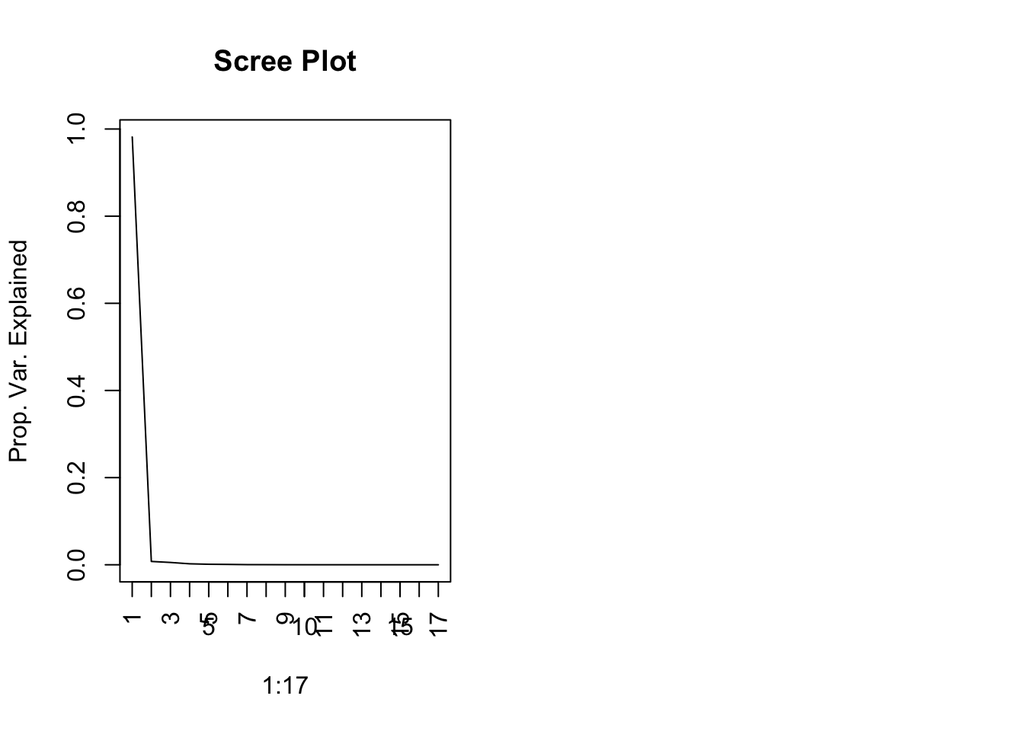

```r
par(mfrow=c(1,2))
eigenvals<-(pc.result2$sdev)^2

plot(1:17,eigenvals/sum(eigenvals),type="l",main="Scree Plot",ylab="Prop. Var. Explained")
axis(1, at = seq(1, 17, by = 1), las=2)
```

2. Provide the eigenvector matrix and examine the loading (coefficients) that determine the linear combinations of each principle component. Veryify that PC1 is eseentially a weighted average of all the variables together (minus the SH, sacrifice hit variable.)

```r
#Eigenvector Matrix
S <- cov(batfull)
S
```

```
##               G          AB           R          H         X2B         X3B
## G    2054.72517  7423.27231 1048.083247 1999.38913  391.509238  40.4922377
## AB   7423.27231 31658.76653 4479.342282 8574.12570 1678.821642 172.8265447
## R    1048.08325  4479.34228  665.778507 1229.55469  240.892334  25.7374659
## H    1999.38913  8574.12570 1229.554688 2363.88035  462.938299  48.0926579
## X2B   391.50924  1678.82164  240.892334  462.93830   96.329514   9.2639032
## X3B    40.49224   172.82654   25.737466   48.09266    9.263903   2.0871050
## HR    287.01946  1227.37641  182.779500  332.32947   65.483920   5.6090096
## RBI  1011.27638  4325.04107  626.830808 1181.47478  234.486247  21.8900185
## SB    120.50739   519.53862   79.319212  145.47607   27.132729   4.3876789
## CS     45.75153   195.44812   29.152609   54.27828   10.319628   1.5322130
## BB    719.42478  3013.70046  446.674872  814.55545  160.232144  16.6039964
## SO   1619.42279  6831.28067  970.046720 1802.62888  355.243673  35.5029711
## IBB    49.87966   209.79975   31.218527   58.76748   11.625996   1.1709569
## HBP    77.48518   323.78516   47.200914   87.68273   17.190928   1.8293544
## SH     13.13605    57.08689    6.671575   14.05549    2.408982   0.5982534
## SF     57.43255   245.22197   35.062837   66.98610   13.164767   1.2991583
## GIDP  172.34493   732.52878  101.332918  199.11415   38.981103   3.3142579
##                HR         RBI         SB          CS          BB         SO
## G     287.0194640 1011.276382 120.507395  45.7515267  719.424778 1619.42279
## AB   1227.3764081 4325.041071 519.538621 195.4481214 3013.700455 6831.28067
## R     182.7795001  626.830808  79.319212  29.1526090  446.674872  970.04672
## H     332.3294736 1181.474778 145.476071  54.2782812  814.555448 1802.62888
## X2B    65.4839203  234.486247  27.132729  10.3196283  160.232144  355.24367
## X3B     5.6090096   21.890019   4.387679   1.5322130   16.603996   35.50297
## HR     61.8421626  189.919911  15.564003   6.0710827  125.699743  285.88263
## RBI   189.9199115  646.443188  61.742296  23.5057184  428.738163  947.08695
## SB     15.5640029   61.742296  25.952024   7.0530147   48.410009  109.19882
## CS      6.0710827   23.505718   7.053015   2.8821470   18.433100   40.88583
## BB    125.6997428  428.738163  48.410009  18.4331001  348.346232  681.08990
## SO    285.8826330  947.086950 109.198822  40.8858348  681.089903 1668.48635
## IBB     9.4961962   32.630691   3.059114   1.0950848   24.451321   44.04827
## HBP    13.0603761   44.653121   5.288528   2.0638346   31.890535   72.51212
## SH      0.2061779    3.814271   2.247308   0.7099476    3.477516   12.04112
## SF      9.9153797   35.844748   3.773404   1.3289949   24.378406   51.39670
## GIDP   28.5556660  102.617835   9.628763   3.7332913   69.559379  151.39792
##              IBB         HBP         SH          SF       GIDP
## G     49.8796614  77.4851802 13.1360493  57.4325518 172.344929
## AB   209.7997462 323.7851598 57.0868921 245.2219682 732.528778
## R     31.2185266  47.2009145  6.6715752  35.0628368 101.332918
## H     58.7674772  87.6827331 14.0554944  66.9861030 199.114149
## X2B   11.6259957  17.1909277  2.4089820  13.1647675  38.981103
## X3B    1.1709569   1.8293544  0.5982534   1.2991583   3.314258
## HR     9.4961962  13.0603761  0.2061779   9.9153797  28.555666
## RBI   32.6306908  44.6531213  3.8142711  35.8447479 102.617835
## SB     3.0591144   5.2885282  2.2473080   3.7734036   9.628763
## CS     1.0950848   2.0638346  0.7099476   1.3289949   3.733291
## BB    24.4513215  31.8905349  3.4775162  24.3784065  69.559379
## SO    44.0482690  72.5121239 12.0411237  51.3966997 151.397916
## IBB    3.4509306   2.3079753  0.1577819   1.9028709   5.106459
## HBP    2.3079753   6.2422188  0.4418921   2.5003194   6.849998
## SH     0.1577819   0.4418921  2.4497667   0.3211362   1.088766
## SF     1.9028709   2.5003194  0.3211362   2.8597884   6.006468
## GIDP   5.1064594   6.8499981  1.0887663   6.0064683  21.165088
```

```r
#Coefficient loadings
pc.result2$rotation
```

```
##              PC1           PC2          PC3          PC4          PC5
## G    0.213191057  9.634960e-01 -0.151757653 -0.028054144  0.031406927
## AB   0.901755626 -2.016421e-01 -0.114190555  0.247945261 -0.005072979
## R    0.127908089 -4.719224e-02  0.005725335 -0.392434357 -0.250293876
## H    0.244280484 -1.269436e-01 -0.283510234 -0.256324196 -0.018720200
## X2B  0.047861479 -2.496044e-02 -0.044739206 -0.080416313  0.045177986
## X3B  0.004920320 -2.242089e-03 -0.011316315  0.004068684 -0.051728880
## HR   0.035193092 -7.899234e-03  0.111293000 -0.243659325  0.244209062
## RBI  0.123598108 -4.632786e-02  0.080081672 -0.586494258  0.608941759
## SB   0.014795306 -1.041542e-02 -0.028704667  0.053951968 -0.286427492
## CS   0.005562903 -2.298801e-03 -0.010612486  0.018715412 -0.085378314
## BB   0.086321684  3.206259e-02  0.178627526 -0.527404337 -0.635288168
## SO   0.195484270  9.298973e-02  0.910235740  0.131350751  0.035584600
## IBB  0.006015504 -7.895414e-04 -0.003188427 -0.071969284 -0.008122328
## HBP  0.009253523  3.588812e-03  0.010731130 -0.011153411 -0.012437473
## SH   0.001590727  2.508194e-05 -0.003681986  0.057007375 -0.039970236
## SF   0.006992190 -2.813248e-03 -0.006224507 -0.027293301  0.018134176
## GIDP 0.020840798 -5.212596e-03 -0.032238719 -0.015244615  0.067012871
##              PC6          PC7          PC8          PC9          PC10
## G     0.03713006  0.001805638  0.001480898 -0.001256269  0.0007240277
## AB   -0.21516207 -0.146899749  0.028043808  0.033242060 -0.0250431798
## R     0.43985726 -0.372487997  0.571498872  0.135940318  0.1617284166
## H     0.51244211  0.622840613 -0.125890696 -0.321852221 -0.0499509303
## X2B   0.10010977  0.285730253 -0.075335375  0.888665676  0.1250332462
## X3B   0.05015479 -0.023390932 -0.013619459  0.037575541 -0.1193349890
## HR    0.01842864 -0.193663953  0.197402480 -0.226842727 -0.0088557097
## RBI  -0.10368104 -0.186399794 -0.321314224  0.067077710 -0.0623326674
## SB    0.40089996 -0.471842593 -0.672846029  0.003567585  0.0729468560
## CS    0.09737788 -0.088745081 -0.119238606  0.019645988 -0.0427800051
## BB   -0.46925166  0.144204859 -0.145054648 -0.030028484 -0.0361480222
## SO    0.24914413  0.190637463 -0.036287261 -0.030939445  0.0352218887
## IBB  -0.04212594  0.035681852 -0.088328569 -0.046132195 -0.1020551034
## HBP   0.02637238 -0.008400064  0.072445977  0.042886445 -0.4991623907
## SH    0.01359474 -0.037820008 -0.037521451  0.009911489  0.0335999340
## SF   -0.02694276 -0.018411222 -0.051224315  0.004437482  0.0180548509
## GIDP -0.12951643  0.080858249 -0.047969368 -0.152925180  0.8161809225
##              PC11          PC12         PC13         PC14          PC15
## G    -0.003016073  0.0045918025 -0.001107765  0.001397153 -0.0012807478
## AB   -0.032537657  0.0032306336  0.003380238 -0.011549267  0.0006522803
## R     0.200458232  0.0519155486  0.056961505 -0.100851881 -0.0196040499
```

[output cut: 17 more lines]

```
## R     0.0674776276 -0.0052309429
## H    -0.0095747262  0.0018999134
## X2B  -0.0452778351  0.0127531682
## X3B  -0.8208249605 -0.1599882546
## HR   -0.2010581908  0.0657130571
## RBI   0.0681321713 -0.0376540739
## SB   -0.0236217642 -0.1549325206
## CS    0.1730788804  0.7783160975
## BB   -0.0144353420 -0.0127262994
## SO    0.0017385009  0.0053437775
## IBB   0.1678608062  0.0467883642
## HBP  -0.0280738299 -0.0239343671
## SH    0.0334985679  0.0063054040
## SF   -0.4510595389  0.5793588540
## GIDP -0.1010140327  0.0055120386
```

```r
mean(pc.result2$rotation[,1])
```

```
## [1] 0.1203274
```

```r
pc.result2$rotation[,2]
```

```
##             G            AB             R             H           X2B
##  9.634960e-01 -2.016421e-01 -4.719224e-02 -1.269436e-01 -2.496044e-02
##           X3B            HR           RBI            SB            CS
## -2.242089e-03 -7.899234e-03 -4.632786e-02 -1.041542e-02 -2.298801e-03
##            BB            SO           IBB           HBP            SH
##  3.206259e-02  9.298973e-02 -7.895414e-04  3.588812e-03  2.508194e-05
##            SF          GIDP
## -2.813248e-03 -5.212596e-03
```

The following data set is a breast cancer data set that has numerous measurements taken from tumor biopsies. The goal of using this data set is to predict using the metrics alone if the biopsy is cancer or not. When continuous variables are available it is often helpful to create a pairs plot of data color coded by the response status (Diagnostis). The first variable is an id number and is not needed.

```r
bc<-read.table("https://archive.ics.uci.edu/ml/machine-learning-databases/breast-cancer-wisconsin/wdbc.data",header=F,sep=",")
names(bc)<- c('id_number', 'diagnosis', 'radius_mean',
              'texture_mean', 'perimeter_mean', 'area_mean',
              'smoothness_mean', 'compactness_mean',
              'concavity_mean','concave_points_mean',
              'symmetry_mean', 'fractal_dimension_mean',
              'radius_se', 'texture_se', 'perimeter_se',
              'area_se', 'smoothness_se', 'compactness_se',
              'concavity_se', 'concave_points_se',
              'symmetry_se', 'fractal_dimension_se',
              'radius_worst', 'texture_worst',
              'perimeter_worst', 'area_worst',
              'smoothness_worst', 'compactness_worst',
              'concavity_worst', 'concave_points_worst',
              'symmetry_worst', 'fractal_dimension_worst')
#Getting a look at the distribution
table(bc$diagnosis)
```

```
##
##   B   M
## 357 212
```

```r
#Scatter plots color coded by response for just the first few variables
#pairs(bc[,3:6],col=bc$diagnosis)
```

Below we will conduct PCA on all of the predictors and plot the first few PC’s against each other and look for speration. The number of PCs to explore can be dictated by the scree plot.

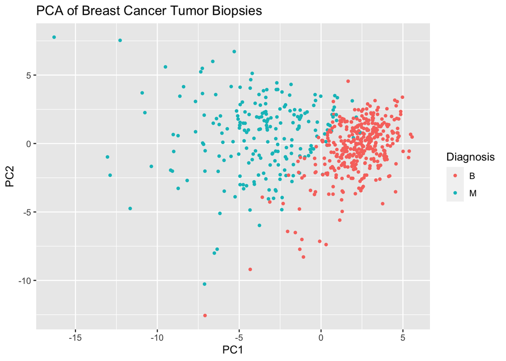

```r
pc.bc<-prcomp(bc[,-c(1,2)],scale.=TRUE)
pc.bc.scores<-pc.bc$x
#Adding the response column to the PC's data frame
pc.bc.scores<-data.frame(pc.bc.scores)
pc.bc.scores$Diagnosis<-bc$diagnosis
#Use ggplot2 to plot the first few pc's
library(ggplot2)
ggplot(data = pc.bc.scores, aes(x = PC1, y = PC2)) +
  geom_point(aes(col=Diagnosis), size=1)+
  ggtitle("PCA of Breast Cancer Tumor Biopsies")
```

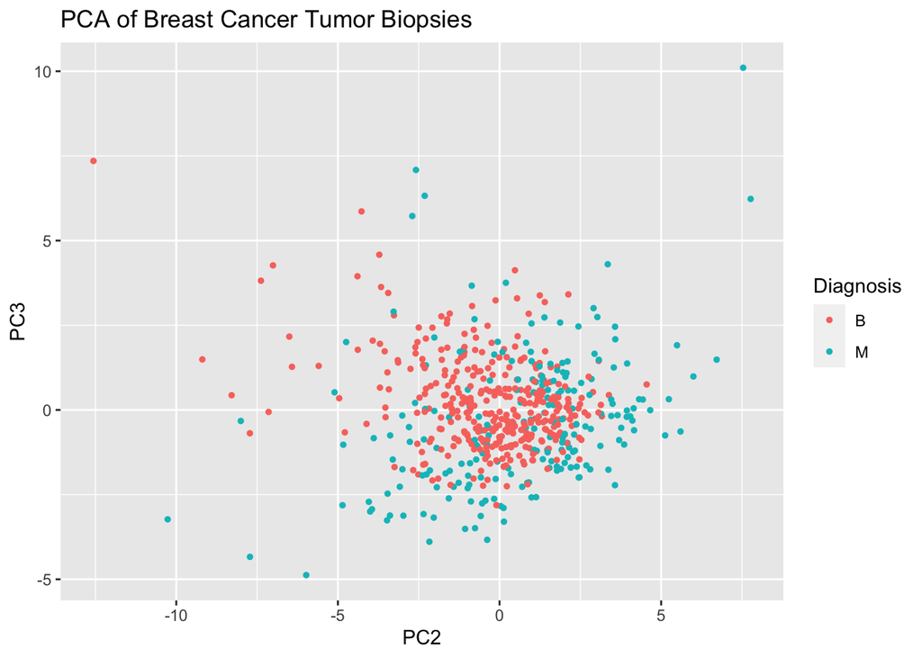

```r
ggplot(data = pc.bc.scores, aes(x = PC2, y = PC3)) +
  geom_point(aes(col=Diagnosis), size=1)+
  ggtitle("PCA of Breast Cancer Tumor Biopsies")
```

So we can see in the first graphic a clear seperation exists for the two cancer groups. So the PCA is telling us in effect what we already know from looking at the original variables. The power of this approach is that you only need to look at 2-4 graphs each time, versus potentially having to examine massive scatterplot matrices to see if anything is there or not!

```r
library(MASS)
mylda<-lda(diagnosis~.,data=bc)
pred<-predict(mylda,newdata=bc)$class  #Predictions can come in many forms, the class form provides the categorical level of your response.
Truth<-bc$diagnosis
x<-table(pred,Truth) # Creating a confusion matrix
x
```

```
##     Truth
## pred   B   M
##    B 355  18
##    M   2 194
```

```r
#Missclassification Error
ME<-(x[2,1]+x[1,2])/569
ME
```

```
## [1] 0.03514938
```

```r
#Calculating overall accuracy
1-ME
```

```
## [1] 0.9648506
```

2. Consider now another great sanity check when building predictive models. The code below takes the original data set and randomly scrambles the response variable. This effectively breaks up any relationship that existed between the predictors and the response.

```r
fake<-bc
fake$diagnosis<-sample(fake$diagnosis,569,replace=F)
```

1. Plot PC1 and PC2 using the scrambled data set.
2. Perform an LDA with this data set and look at the confusion matrix. Do they correspond?

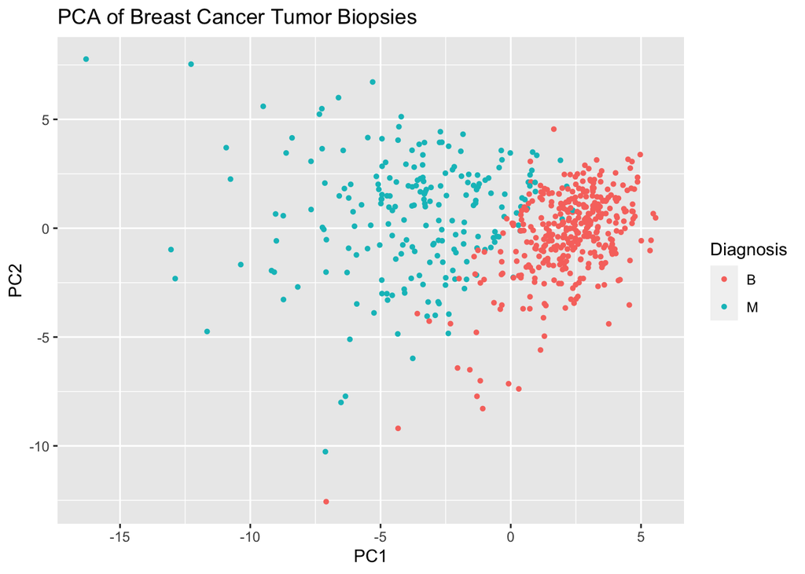

```r
#A)
pc.bc<-prcomp(fake[,-c(1,2)],scale.=TRUE)
pc.bc.scores<-pc.bc$x
#Adding the response column to the PC's data frame
pc.bc.scores<-data.frame(pc.bc.scores)
pc.bc.scores$Diagnosis<-bc$diagnosis
#Use ggplot2 to plot the first few pc's
library(ggplot2)
ggplot(data = pc.bc.scores, aes(x = PC1, y = PC2)) +
  geom_point(aes(col=Diagnosis), size=1)+
  ggtitle("PCA of Breast Cancer Tumor Biopsies")
```

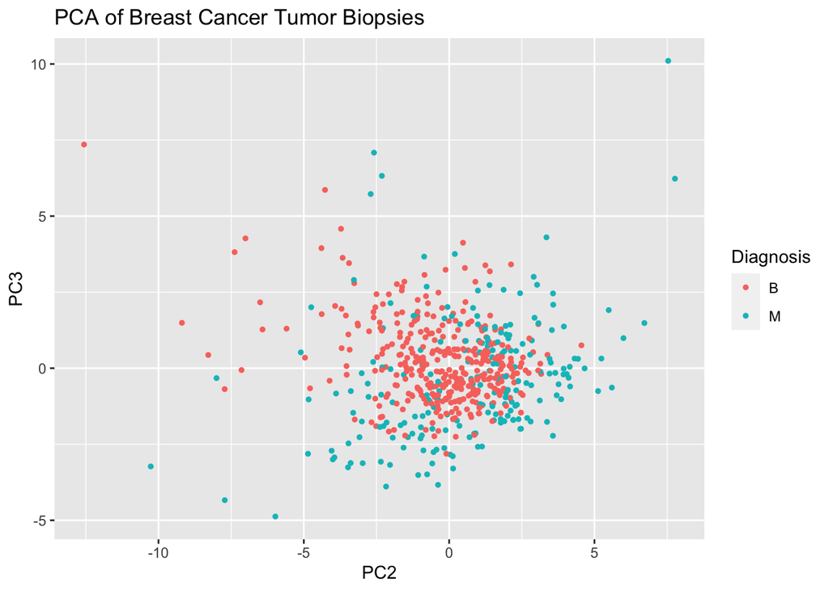

```r
ggplot(data = pc.bc.scores, aes(x = PC2, y = PC3)) +
  geom_point(aes(col=Diagnosis), size=1)+
  ggtitle("PCA of Breast Cancer Tumor Biopsies")
```

```r
#B)
mylda<-lda(diagnosis~.,data=fake)
pred<-predict(mylda,newdata=fake)$class  #Predictions can come in many forms, the class form provides the categorical level of your response.
Truth<-bc$diagnosis
x<-table(pred,Truth) # Creating a confusion matrix
x
```

```
##     Truth
## pred   B   M
##    B 313 192
##    M  44  20
```

```r
#Missclassification Error
ME<-(x[2,1]+x[1,2])/569
ME
```

```
## [1] 0.4147627
```

```r
#Calculating overall accuracy
1-ME
```

```
## [1] 0.5852373
```

Note: This little trick is extremely helpful when you are predicting a response that is heavily imbalance (ex: lots of Cancer obs, few Healthy ones ). LDA and other algorithms can behave quite wierdly in extreme cases and prediction performances can look good all the time. By conducting a seperate analysis on scrambled data, if the prediction performance still looks good, you’ve recognized a problem. We can discuss this topic more as we get closer to finishing up Project 2.